[figure not shown]

# Student Performance

1. Introduction
   - 1.1 Data Dictionary
   - 1.2 Task
2. Preparation
   - 2.1 Packages
   - 2.2 Loading Data
   - 2.3 Understanding Data
3. Exploratory Data Analysis
   - 3.1 Univariate Analysis
   - 3.2 Bivariate Analysis

### 1. Introduction

The dataset used in this notebook is from [University of California at Irvine (UCI) Repository](https://archive.ics.uci.edu/ml/datasets/student+performance). The student performance data contain math, and portuguese language data. We will at the mathematical performance of students in this notebook.

#### 1.1 Data Dictionary

`school` - student's school (Categorical: GP = Gabriel Pereira, MS = Mousinho da Silveira)

`sex` - student's sex (Categorical: F = female, M = male)

`age` - student's age (numeric)

`address` - student's home address type (Categorical: U = urban, R = rural)

`famsize` - family size (Categorical: LE3 = less or equal to 3, GT3 = greater than 3)

`Pstatus` - parent's cohabitation status (Categorical: T = living together, A = apart)

`Medu` - mother's education (Categorical: 0 = none, 1 = primary education (4th grade), 2 = 5th to 9th grade, 3 = secondary education or 4 = higher education)

`Fedu` - father's education (Categorical: 0 = none, 1 = primary education (4th grade), 2 = 5th to 9th grade, 3 = secondary education or 4 = higher education)

`Mjob` - mother's job (Categorical: 'teacher', 'health' care related, civil 'services' (e.g. administrative or police), 'at_home' or 'other')

`Fjob` - father's job (Categorical: 'teacher', 'health' care related, civil 'services' (e.g. administrative or police), 'at_home' or 'other')

`reason` - reason to choose this school (Categorical: close to home, school reputation, course' preference or other)

`guardian` - student's guardian (Categorical: mother, father or other)

`traveltime` - home to school travel time (Categorical: 1: <15 min., 2: 15 to 30 min., 3: 30 min. to 1 hour, or 4: >1 hour)

`studytime` - weekly study time (Categorical: 1 - <2 hours, 2 - 2 to 5 hours, 3 - 5 to 10 hours, or 4 - >10 hours)

`failures` - number of past class failures (numeric)

`schoolsup` - extra educational support (Categorical: yes, no)

`famsup` - family educational support (Categorical: yes, no)

`paid` - extra paid classes within the course subject (Categorical: yes, no)

`activities` - extra-curricular activities (Categorical: yes, no)

`nursery` - attended nursery school (Categorical: yes, no)

`higher` - wants to take higher education (Categorical: yes, no)

`internet` - Internet access at home (Categorical: yes, no)

`romantic` - with a romantic relationship (Categorical: yes, no)

`famrel` - quality of family relationships (Numeric: from 1 - very bad to 5 - excellent)

`freetime` - free time after school (Numeric: from 1 - very low to 5 - very high)

`goout` - going out with friends (Numeric: from 1 - very low to 5 - very high)

`Dalc` - workday alcohol consumption (Numeric: from 1 - very low to 5 - very high)

`Walc` - weekend alcohol consumption (Numeric: from 1 - very low to 5 - very high)

`health` - current health status (Numeric: from 1 - very bad to 5 - very good)

`absences` - number of school absences (Numeric: from 0 to 93)

`G1` - first period grade (Numeric: from 0 to 20)

`G2` - second period grade (Numeric: from 0 to 20)

`G3` - final grade (Numeric: from 0 to 20, output target)

#### 1.2 Task

Perform exploratory data analysis (EDA).

### 2. Preparation

We will install packages, and do some preliminary inspections of the data.

#### 2.1 Packages

```python
import pandas as pd
import numpy as np
import matplotlib.pyplot as plt
import seaborn as sns
import warnings
warnings.filterwarnings("ignore")
```

#### 2.2 Loading Data

```python
df_1 = pd.read_csv("./data/student_data.csv")
```

```python
df_1
```

|  | school | sex | age | address | famsize | Pstatus | Medu | Fedu | Mjob | Fjob | ... | famrel | freetime | goout | Dalc | Walc | health | absences | G1 | G2 | G3 |
| --- | --- | --- | --- | --- | --- | --- | --- | --- | --- | --- | --- | --- | --- | --- | --- | --- | --- | --- | --- | --- | --- |
| 0 | GP | F | 18 | U | GT3 | A | 4 | 4 | at_home | teacher | ... | 4 | 3 | 4 | 1 | 1 | 3 | 6 | 5 | 6 | 6 |
| 1 | GP | F | 17 | U | GT3 | T | 1 | 1 | at_home | other | ... | 5 | 3 | 3 | 1 | 1 | 3 | 4 | 5 | 5 | 6 |
| 2 | GP | F | 15 | U | LE3 | T | 1 | 1 | at_home | other | ... | 4 | 3 | 2 | 2 | 3 | 3 | 10 | 7 | 8 | 10 |
| 3 | GP | F | 15 | U | GT3 | T | 4 | 2 | health | services | ... | 3 | 2 | 2 | 1 | 1 | 5 | 2 | 15 | 14 | 15 |
| 4 | GP | F | 16 | U | GT3 | T | 3 | 3 | other | other | ... | 4 | 3 | 2 | 1 | 2 | 5 | 4 | 6 | 10 | 10 |
| ... | ... | ... | ... | ... | ... | ... | ... | ... | ... | ... | ... | ... | ... | ... | ... | ... | ... | ... | ... | ... | ... |
| 390 | MS | M | 20 | U | LE3 | A | 2 | 2 | services | services | ... | 5 | 5 | 4 | 4 | 5 | 4 | 11 | 9 | 9 | 9 |
| 391 | MS | M | 17 | U | LE3 | T | 3 | 1 | services | services | ... | 2 | 4 | 5 | 3 | 4 | 2 | 3 | 14 | 16 | 16 |
| 392 | MS | M | 21 | R | GT3 | T | 1 | 1 | other | other | ... | 5 | 5 | 3 | 3 | 3 | 3 | 3 | 10 | 8 | 7 |
| 393 | MS | M | 18 | R | LE3 | T | 3 | 2 | services | other | ... | 4 | 4 | 1 | 3 | 4 | 5 | 0 | 11 | 12 | 10 |
| 394 | MS | M | 19 | U | LE3 | T | 1 | 1 | other | at_home | ... | 3 | 2 | 3 | 3 | 3 | 5 | 5 | 8 | 9 | 9 |

395 rows × 33 columns

One thing I'm noticing from the get-go is some of the data are categorical, but they are in characters, rather than numerical value. Before we do predictions, we'll need to vectorize these columns.

#### 2.3 Understanding the Data

##### 2.3.1 Preview of the Data

```python
df_1.head()
```

|  | school | sex | age | address | famsize | Pstatus | Medu | Fedu | Mjob | Fjob | ... | famrel | freetime | goout | Dalc | Walc | health | absences | G1 | G2 | G3 |
| --- | --- | --- | --- | --- | --- | --- | --- | --- | --- | --- | --- | --- | --- | --- | --- | --- | --- | --- | --- | --- | --- |
| 0 | GP | F | 18 | U | GT3 | A | 4 | 4 | at_home | teacher | ... | 4 | 3 | 4 | 1 | 1 | 3 | 6 | 5 | 6 | 6 |
| 1 | GP | F | 17 | U | GT3 | T | 1 | 1 | at_home | other | ... | 5 | 3 | 3 | 1 | 1 | 3 | 4 | 5 | 5 | 6 |
| 2 | GP | F | 15 | U | LE3 | T | 1 | 1 | at_home | other | ... | 4 | 3 | 2 | 2 | 3 | 3 | 10 | 7 | 8 | 10 |
| 3 | GP | F | 15 | U | GT3 | T | 4 | 2 | health | services | ... | 3 | 2 | 2 | 1 | 1 | 5 | 2 | 15 | 14 | 15 |
| 4 | GP | F | 16 | U | GT3 | T | 3 | 3 | other | other | ... | 4 | 3 | 2 | 1 | 2 | 5 | 4 | 6 | 10 | 10 |

5 rows × 33 columns

```python
df_1.columns.values.tolist()
```

```
['school',
 'sex',
 'age',
 'address',
 'famsize',
 'Pstatus',
 'Medu',
 'Fedu',
 'Mjob',
 'Fjob',
 'reason',
 'guardian',
 'traveltime',
 'studytime',
 'failures',
 'schoolsup',
 'famsup',
 'paid',
 'activities',
 'nursery',
 'higher',
 'internet',
 'romantic',
 'famrel',
 'freetime',
 'goout',
 'Dalc',
 'Walc',
 'health',
 'absences',
 'G1',
 'G2',
 'G3']
```

##### 2.3.2 Determining if there are non-numerical values

```python
df_1.info()
```

```
<class 'pandas.core.frame.DataFrame'>
RangeIndex: 395 entries, 0 to 394
Data columns (total 33 columns):
 #   Column      Non-Null Count  Dtype
---  ------      --------------  -----
 0   school      395 non-null    object
 1   sex         395 non-null    object
 2   age         395 non-null    int64
 3   address     395 non-null    object
 4   famsize     395 non-null    object
 5   Pstatus     395 non-null    object
 6   Medu        395 non-null    int64
 7   Fedu        395 non-null    int64
 8   Mjob        395 non-null    object
 9   Fjob        395 non-null    object
```

[output cut: 25 more lines]

##### 2.3.3 Total number of rows, columns

```python
df_1.shape
```

```
(395, 33)
```

##### 2.3.4 Summary Statistics

```python
df_1.describe()
```

|  | age | Medu | Fedu | traveltime | studytime | failures | famrel | freetime | goout | Dalc | Walc | health | absences | G1 | G2 | G3 |
| --- | --- | --- | --- | --- | --- | --- | --- | --- | --- | --- | --- | --- | --- | --- | --- | --- |
| count | 395.000000 | 395.000000 | 395.000000 | 395.000000 | 395.000000 | 395.000000 | 395.000000 | 395.000000 | 395.000000 | 395.000000 | 395.000000 | 395.000000 | 395.000000 | 395.000000 | 395.000000 | 395.000000 |
| mean | 16.696203 | 2.749367 | 2.521519 | 1.448101 | 2.035443 | 0.334177 | 3.944304 | 3.235443 | 3.108861 | 1.481013 | 2.291139 | 3.554430 | 5.708861 | 10.908861 | 10.713924 | 10.415190 |
| std | 1.276043 | 1.094735 | 1.088201 | 0.697505 | 0.839240 | 0.743651 | 0.896659 | 0.998862 | 1.113278 | 0.890741 | 1.287897 | 1.390303 | 8.003096 | 3.319195 | 3.761505 | 4.581443 |
| min | 15.000000 | 0.000000 | 0.000000 | 1.000000 | 1.000000 | 0.000000 | 1.000000 | 1.000000 | 1.000000 | 1.000000 | 1.000000 | 1.000000 | 0.000000 | 3.000000 | 0.000000 | 0.000000 |
| 25% | 16.000000 | 2.000000 | 2.000000 | 1.000000 | 1.000000 | 0.000000 | 4.000000 | 3.000000 | 2.000000 | 1.000000 | 1.000000 | 3.000000 | 0.000000 | 8.000000 | 9.000000 | 8.000000 |
| 50% | 17.000000 | 3.000000 | 2.000000 | 1.000000 | 2.000000 | 0.000000 | 4.000000 | 3.000000 | 3.000000 | 1.000000 | 2.000000 | 4.000000 | 4.000000 | 11.000000 | 11.000000 | 11.000000 |
| 75% | 18.000000 | 4.000000 | 3.000000 | 2.000000 | 2.000000 | 0.000000 | 5.000000 | 4.000000 | 4.000000 | 2.000000 | 3.000000 | 5.000000 | 8.000000 | 13.000000 | 13.000000 | 14.000000 |
| max | 22.000000 | 4.000000 | 4.000000 | 4.000000 | 4.000000 | 3.000000 | 5.000000 | 5.000000 | 5.000000 | 5.000000 | 5.000000 | 5.000000 | 75.000000 | 19.000000 | 19.000000 | 20.000000 |

##### 2.3.5 Discrete and Continuous Features

```python
cat = ['school','sex','age', 'address', 'famsize', 'Pstatus', 'Medu', 'Fedu', 'Mjob', 'Fjob', 'reason',
       'guardian', 'traveltime', 'studytime', 'failures', 'schoolsup', 'famsup', 'paid', 'activities',
       'nursery', 'higher', 'internet', 'romantic', 'famrel', 'freetime', 'goout', 'Dalc', 'Walc', 'health']
con = ['absences', 'G1', 'G2']
output = ['G3']


print ("The categorcial features are:", cat, "\n")
print ("The continuous features are:", con, "\n")
print ("The target variable is:", output)
```

```
The categorcial features are: ['school', 'sex', 'age', 'address', 'famsize', 'Pstatus', 'Medu', 'Fedu', 'Mjob', 'Fjob', 'reason', 'guardian', 'traveltime', 'studytime', 'failures', 'schoolsup', 'famsup', 'paid', 'activities', 'nursery', 'higher', 'internet', 'romantic', 'famrel', 'freetime', 'goout'…

The continuous features are: ['absences', 'G1', 'G2']

The target variable is: ['G3']
```

### 3. Exploratory Data Analysis

#### 3.1 Univariate Analysis

##### 3.1.1 Analysis of Categorical Features

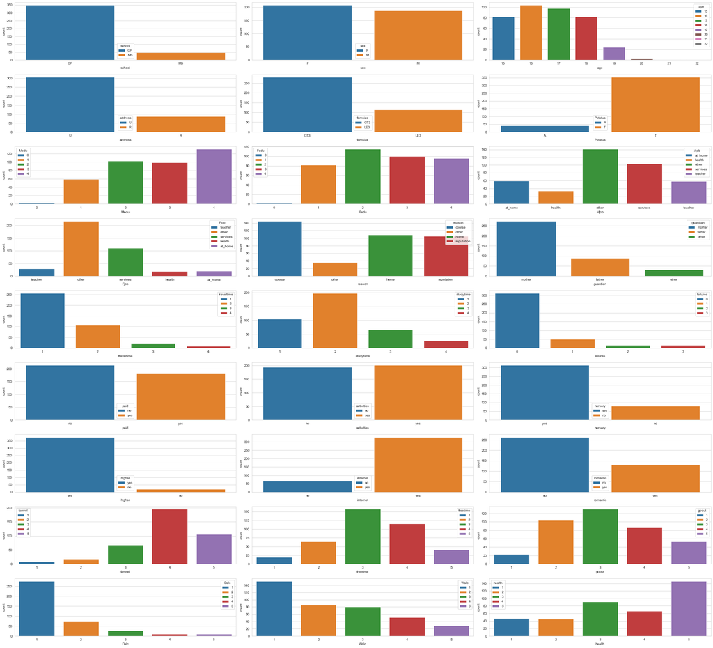

```python
sns.set_style("whitegrid")
count_cat_names = []
cat_values = []

for i in df_1.columns:
    if i in cat:
        count_cat_names.append("Countplot for " + i)
        cat_values.append(df_1[i].value_counts().index.tolist())

fig, ax = plt.subplots(10, 3, figsize=(30,30))

#countplot for school category
ax1 = sns.countplot(data=df_1, x='school', hue='school', dodge=False, ax=ax[0,0])

#countplot for sex category
ax2 = sns.countplot(data=df_1, x='sex', hue='sex', dodge=False, ax=ax[0,1])

#countplot for age category
ax3 = sns.countplot(data=df_1, x='age', hue='age', dodge=False, ax=ax[0,2])

#countplot for address category
ax4 = sns.countplot(data=df_1, x='address', hue='address', dodge=False, ax=ax[1,0])

#countplot for famsize category
ax5 = sns.countplot(data=df_1, x='famsize', hue='famsize', dodge=False, ax=ax[1,1])

#countplot for Pstatus category
ax6 = sns.countplot(data=df_1, x='Pstatus', hue='Pstatus', dodge=False, ax=ax[1,2])

#countplot for Medu category
ax7 = sns.countplot(data=df_1, x='Medu', hue='Medu', dodge=False, ax=ax[2,0])

#countplot for Fedu category
ax8 = sns.countplot(data=df_1, x='Fedu', hue='Fedu', dodge=False, ax=ax[2,1])

#countplot for Mjob category
ax9 = sns.countplot(data=df_1, x='Mjob', hue='Mjob', dodge=False, ax=ax[2,2])

#countplot for Fjob category
ax10 = sns.countplot(data=df_1, x='Fjob', hue='Fjob', dodge=False, ax=ax[3,0])

#countplot for reason category
ax11 = sns.countplot(data=df_1, x='reason', hue='reason', dodge=False, ax=ax[3,1])

#countplot for guardian category
ax12 = sns.countplot(data=df_1, x='guardian', hue='guardian', dodge=False, ax=ax[3,2])

#countplot for traveltime category
ax13 = sns.countplot(data=df_1, x='traveltime', hue='traveltime', dodge=False, ax=ax[4,0])

#countplot for studytime category
ax14 = sns.countplot(data=df_1, x='studytime', hue='studytime', dodge=False, ax=ax[4,1])

#countplot for failures category
ax15 = sns.countplot(data=df_1, x='failures', hue='failures', dodge=False, ax=ax[4,2])

#countplot for paid category
ax16 = sns.countplot(data=df_1, x='paid', hue='paid', dodge=False, ax=ax[5,0])

#countplot for activities category
ax17 = sns.countplot(data=df_1, x='activities', hue='activities', dodge=False, ax=ax[5,1])

#countplot for nursery category
ax18 = sns.countplot(data=df_1, x='nursery', hue='nursery', dodge=False, ax=ax[5,2])

#countplot for higher category
ax19 = sns.countplot(data=df_1, x='higher', hue='higher', dodge=False, ax=ax[6,0])

#countplot for internet category
ax20 = sns.countplot(data=df_1, x='internet', hue='internet', dodge=False, ax=ax[6,1])

#countplot for romantic category
ax21 = sns.countplot(data=df_1, x='romantic', hue='romantic', dodge=False, ax=ax[6,2])

#countplot for famrel category
ax22 = sns.countplot(data=df_1, x='famrel', hue='famrel', dodge=False, ax=ax[7,0])

#countplot for freetime category
ax23 = sns.countplot(data=df_1, x='freetime', hue='freetime', dodge=False, ax=ax[7,1])

#countplot for goout category
ax24 = sns.countplot(data=df_1, x='goout', hue='goout', dodge=False, ax=ax[7,2])

#countplot for Dalc category
ax25 = sns.countplot(data=df_1, x='Dalc', hue='Dalc', dodge=False, ax=ax[8,0])

#countplot for Walc category
ax26 = sns.countplot(data=df_1, x='Walc', hue='Walc', dodge=False, ax=ax[8,1])

#countplot for health category
ax27 = sns.countplot(data=df_1, x='health', hue='health', dodge=False, ax=ax[8,2])


fig.tight_layout()
fig.delaxes(ax[9,0])
fig.delaxes(ax[9,1])
fig.delaxes(ax[9,2])
```